# ASReview report

This report is an example of the output from an [open source tool](https://github.com/langtonhugh/asreview_irr) which makes it easier to compare the decisions by two raters after screening literature samples in [ASReview](https://asreview.nl/). The report can be created automatically using the .csv files downloaded directly from the ASReview dashboard. The report is a work-in-progress. If you are an R user, please take a look at the [source code](https://github.com/langtonhugh/asreview_irr/blob/main/report_example.Rmd). Checks, feedback and suggestions for additional features are welcome. You can find my contact details on [my website](https://www.samlangton.info/).

# 1 Files used

File 1 (selected for rater A):

```
C:\Users\P090168\GitHub\asreview_irr\data\asreview_result_spatial-and-temporal-patterning-of-emergency-reactive-police-demand.csv
```

File 2 (selected for rater B):

```
C:\Users\P090168\GitHub\asreview_irr\data\asreview_result_spatial-and-temporal-patterning-of-emergency-reactive-police-demand-2nd-coder.csv
```

# 2 Rater summary

|  | rater A | rater B |
| --- | --- | --- |
| n uploaded | 3103 | 3103 |
| n reviewed | 489 | 535 |
| % reviewed | 15.76 | 17.24 |
| n flagged relevant | 115 | 82 |
| n flagged irrelevant | 374 | 453 |
| % flagged relevant | 23.52 | 15.33 |
| n unreviewed | 2614 | 2568 |
| n unreviewed + irrelevant | 2988 | 3021 |
| % total relevant | 3.71 | 2.64 |
| n relevant v. irrelevant | 39 | 5 |
| n relevant v. unreviewed | 0 | 1 |

# 3 Overall summary

| Description | n |
| --- | --- |
| Both rated irrelevant | 325 |
| One rated relevant, other irrelevant | 44 |
| Both rated relevant | 76 |
| One rated irrelevant, other left unreviewed | 133 |
| One rated relevant, other left unreviewed | 1 |
| Both left unreviewed | 2524 |
| Both raters made decision | 445 |

# 4 Written explanations

- Reviewer A evaluated 489 of 3103 articles (15.76%), of which (s)he flagged 115 as relevant and 374 as irrelevant.
- Reviewer B evaluated 535 of 3103 articles (17.24%), of which (s)he flagged 82 as relevant and 453 as irrelevant.
- Rater A left a total of 2614 articles unreviewed, while rater B left 2568 unreviewed. In other words, these articles lay beyond the ‘stop rule’ and were never seen by the raters.
- Rater A flagged 0 article(s) as relevant that rater B left unreviewed. This figure for Rater B was 1.
- The ‘total irrelevant’ figure is the sum of (1) the number of articles actively flagged as irrelevant by raters and (2) the number of articles left unreviewed after the stop rule (and therefore assumed to be irrelevant).
- Rater A flagged 39 articles as relevant that rater B flagged as irrelevant. Conversely, rater B flagged 5 articles as relevant that rater B flagged as irrelevant.

# 5 Visual summary

## 5.1 Proportional breakdown

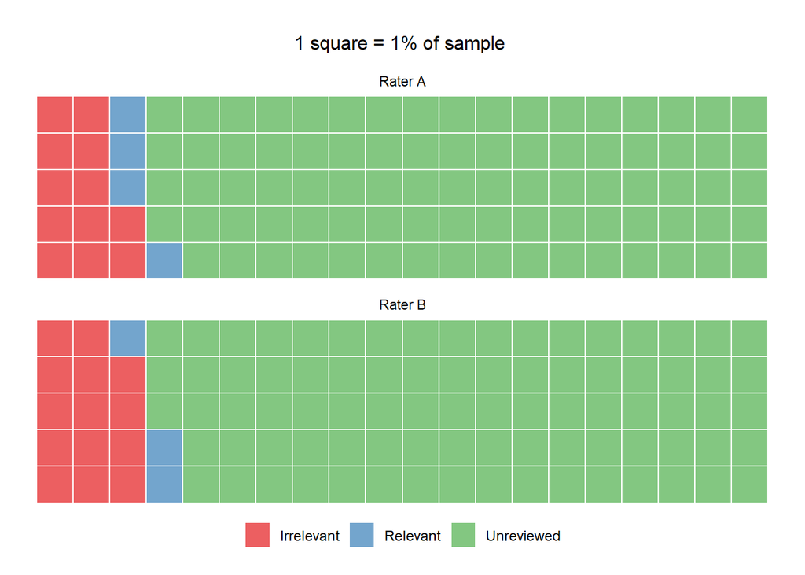

## 5.2 Rater overlap

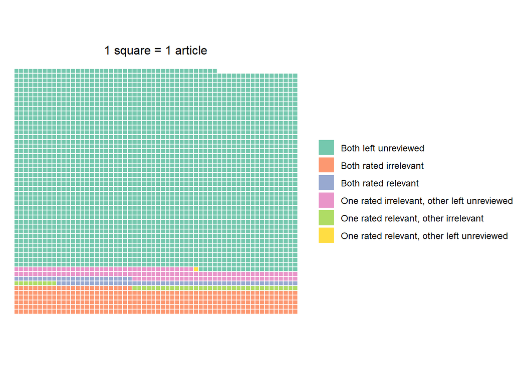

# 6 Comparison of different IRR methods

Here we present different methods to calculate the inter-rater reliability (IRR).

CAUTION! We are still actively researching what method is most appropriate to calculate the IRR. It is not straightforward because the unrated items of both raters (the items that ASReview deems less relevant), depend on what you rated beforehand. This is not the kind of situation that most IRR-statistics are equipped to handle. If they are equipped to deal with unrated items, it is assumed that the missing data is random. For now, we recommend using Gwet’s kappa using listwise deletion. Note that this recommendation may change in the future.

The level of agreement between rater A and rater B is the following:

```
##  Percentage agreement (Tolerance=0)
##
##  Subjects = 445
##    Raters = 2
##   %-agree = 90.1
```

## 6.1 Cohen’s kappa statistic (with missings coded as `-1`):

Cohen’s kappa is used to measure the agreement between raters, correcting for chance alone. In this version, the missings are coded, which means that they are counted among the data. A downside of this method is that it can artificially inflate agreement rates because it treats missing values the same as observed values. It skews the results by giving undue weight to unrated items as it treats them the same as the observed values.

```
##  Cohen's Kappa for 2 Raters (Weights: unweighted)
##
##  Subjects = 2969
##    Raters = 2
##     Kappa = 0.944
##
##         z = 60.9
##   p-value = 0
```

## 6.2 Cohen’s kappa statistic (with listwise deletion):

Cohen’s kappa is used to measure the agreement between raters, correcting for chance alone. In this version, cases with missing values are excluded from the analysis. By only considering cases where both raters provided data, it provides a cleaner estimate of agreement between raters. This can reduce bias introduced by missing data and may provide a more accurate representation of true agreement.

```
##  Cohen's Kappa for 2 Raters (Weights: unweighted)
##
##  Subjects = 445
##    Raters = 2
##     Kappa = 0.715
##
##         z = 15.5
##   p-value = 0
```

## 6.3 Gwet’s coefficient (with missings coded as `-1`)

Gwet’s Kappa incorporates a prevalence adjustment. By weighting agreement based on the prevalence of the categories being rated, it aims to provide a more balanced measure of agreement. The increased complexity means that it can be more difficult to interpret. In this version, the missings are coded, which means that they are counted among the data. A downside of this method is that it can artificially inflate agreement rates because it treats missing values the same as observed values. It skews the results by giving undue weight to unrated items as it treats them the same as the observed values.

```
## $est
##   coeff.name        pa        pe coeff.val coeff.se      conf.int p.value
## 1        AC1 0.9851802 0.1567117   0.98243  0.00463 (0.973,0.992)       0
##       w.name
## 1 unweighted
##
## $weights
##      [,1] [,2] [,3]
## [1,]    1    0    0
## [2,]    0    1    0
## [3,]    0    0    1
##
## $categories
## [1] -1  0  1
```

## 6.4 Gwet’s coefficient (with listwise deletion):

Gwet’s Kappa incorporates a prevalence adjustment. By weighting agreement based on the prevalence of the categories being rated, it can result in a more balanced measure of agreement. By only considering cases where both raters provided data, it provides a cleaner estimate of agreement between raters. This can reduce bias introduced by missing data and may provide a more accurate representation of true agreement.

```
## $est
##   coeff.name        pa        pe coeff.val coeff.se      conf.int p.value
## 1        AC1 0.9011236 0.3434516    0.8494  0.02315 (0.804,0.895)       0
##       w.name
## 1 unweighted
##
## $weights
##      [,1] [,2]
## [1,]    1    0
## [2,]    0    1
##
## $categories
## [1] 0 1
```

## 6.5 Krippendorff’s alpha (with listwise deletion):

Krippendorff’s alpha is a generalization of Cohen’s kappa that can handle multiple raters. It has no prevalance correction (see Gwet’s kappa).

```
##  Krippendorff's alpha
##
##  Subjects = 3103
##    Raters = 2
##     alpha = 0.712
```

# 7 Disagreements

## 7.1 Relevant versus unreviewed

If there are any, the following are the articles for which one rater flagged ‘relevant’ and the other did not review it because it lay beyond the stop rule.

| id | author(s) | year | title | abstract |
| --- | --- | --- | --- | --- |
| 503 | Frailing, K, Zawisza, T, Harper, D W | 2021 | Whirlwinds and Break-Ins: Evidence Linking a New Orleans Tornado to Residential Burglary | This study examines the number and location of residential burglaries before and after a tornado that struck New Orleans, Louisiana in February 2017. Using calls for service to the New Orleans Police … |

## 7.2 Rater A

Studies for which rater A flagged relevant and rater B flagged irrelevant.

| id | author(s) | year | title | abstract |
| --- | --- | --- | --- | --- |
| 2404 | Melo, S N, Boivin, R, Morselli, C | 2020 | Spatial dark figures of rapes: (In)Consistencies across police and hospital data | The dark figures of crime are occurrences that, by some criteria, are called crime yet that are not registered in the official statistics. According to several studies, only a few rapes are reported t… |
| 303 | Wu, X Y, Lum, C | 2017 | Measuring the Spatial and Temporal Patterns of Police Proactivity | To measure where officers engage in proactive, self-initiated activities, how much time they spend being proactive, and whether their proactive activities coincide with crime patterns. This study uses… |
| 2163 | Deryol, R, Payne, T C | 2018 | A method of identifying dark-time crime locations for street lighting purposes | Research on the effect of street lighting on crime and fear of crime has received much attention, especially between 1970s and early 2000s. Yet no study has documented an empirical method for choosing… |
| 2107 | Liu, X Y, Carter, J, Ray, B, Mohler, G | 2021 | POINT PROCESS MODELING OF DRUG OVERDOSES WITH HETEROGENEOUS AND MISSING DATA | Opioid overdose rates have increased in the United States over the past decade and reflect a major public health crisis. Modeling and prediction of drug and opioid hotspots, where a high percentage of… |
| 119 | Lebeau, J L | 2002 | The impact of a hurricane on routine activities and on calls for police service: Charlotte, north carolina, and hurricane hugo | Cohen and Felson’s routine activity theory asserts that crime occurs when motivated offenders converge in time and space with targets lacking capable guardianship. Crime is a product of our normal eve… |
| 130 | Decker, S H, Varano, S P, Greene, J R | 2007 | Routine crime in exceptional times: The impact of the 2002 Winter Olympics on citizen demand for police services | Despite their rich theoretical and practical importance, criminologists have paid scant attention to the patterns of crime and the responses to crime during exceptional events. Throughout the world la… |
| 83 | Bennett, Richard R | 2004 | Calling for Service: Mobilization of the Police Across Sociocultural Environments. | Although researchers have investigated the nature and distribution of routine police activity over the past 30 years, surprisingly few analyses have explained the observed variation in these activitie… |
| 873 | Saunders, J, Dongarwar, D, Salemi, J, Schulte, J, Persse, D, Matin, A, Banu, S, Shah, A | 2021 | Emergency mental health calls to first responders following a natural disaster: Examining the effects from Hurricane Harvey | Introduction: Hurricane Harvey which made landfall on August 25, 2017 was a devastating storm that dumped unprecedented amount of rainfall on the area including Houston, Texas, United States of Americ… |
| 23 | Gaston, S | 2019 | Enforcing Race: A Neighborhood-Level Explanation of Black-White Differences in Drug Arrests | This research investigates the source of Black-White differences in drug arrests by conducting a neighborhood-level test of the differential police scrutiny and racially discriminatory policing hypoth… |
| 177 | DeCarlo, John, Sainato, Vincenzo, Ackerman, Alissa | 2008 | Mythbusted: Using Data Mining to Assess Police Calls For Service, Offender Aggression, And The Environment. | It has been speculated for years that there are relationships and patterns between human behavior, aggression, and certain ecological, temporal and biological factors. In policing, certain ideas conne… |
| 171 | Taniguchi, T A, Salvatore, C | 2018 | Policing a Negotiated World: A Partial Test of Klinger’s Ecological Theory of Policing | Klinger’s (Criminology 35(2): 277-306, 1997) ecological theory of policing addresses the intersection of environment and police organizational structure on police patrol practices. The current study a… |
| 1106 | Liu, L, Eck, J | 2007 | Analysis of police vehicle stops in Cincinnati: A geographic perspective | This study analyzes police vehicle stop data collected during the second half of 2001. In addition to addressing questions such as who is stopped and why vehicles are stopped, this article focuses on … |
| 234 | Simpson, R, Hipp, J R | 2019 | What came first: the police or the incident? Bidirectional relationships between police actions and police incidents | The present research examines the long-term, bidirectional relationships between calls for service, crime, and two police patrol strategies in Santa Monica, California: foot patrol and police stops. U… |
| 520 | Johnson, Richard R, Doerle, Kevin H | 2016 | Measuring the Effects of a Terrorist Attack on Community Crime and Incivilities. | Criminology has only just begun to examine the effects of major events, such as terrorism or natural disasters, on normal crime and disorder. This study examined the influence the terrorist incidents … |
| 473 | St. Louis, Stacie, Greene, Jack R | 2020 | Social context in police legitimacy: giving meaning to police/community contacts. | The history of policing in the United States is a history of tension between the police and the public, especially in marginalised communities, where the legitimacy of the police and their interventio… |
| 3032 | Verma, A | 1998 | The fractal dimension of policing | Crime is inherent in our society and the routine activities of everyday life ensure that circumstances will be created that will facilitate criminal behavior The very nature of society-the need to go … |
| 2304 | Moyer, R A | NA | The Effect of a Death-in-Police-Custody Incident on Community Reliance on the Police | Objectives Examine whether a death-in-police-custody incident affected community reliance on the police, as measured through citizen calls requesting police assistance for non-criminal caretaking matt… |
| 594 | Phillips, Scott W, Gayadeen, S Marlon, Kim, Dae-Young, OâNeil, Jennifer L, Robertson, Joshua | \|201 | \|A partial test of the ecological theory: Examining vigour at the block group level. | \|Klinger (1997) advanced research on police behaviour when he developed his ecological theory as a means to predict or explain the influence of the âpatrol districtâ on police behaviour. He propo… |
| 1977 | Curtis, A, Curtis, J W, Porter, L C, Jefferis, E, Shook, E | 2016 | Context and Spatial Nuance Inside a Neighborhood’s Drug Hotspot: Implications for the Crime-Health Nexus | New geographic approaches are required to tease apart the underlying sociospatial complexity of neighborhood decline to target appropriate interventions. Typically maps of crime hotspots are used with… |
| 126 | Heller, N B, Markland, R E | 1970 | A Climatological Model for Forecasting the Demand for Police Service | The rate of citizen calls for police service exhibits marked seasonal fluctuations, generally reaching a peak during the summer months and slacking off to a low point in midwinter. Data from St. Louis… |
| 2368 | Quinet, K D, Nunn, S | 1998 | Illuminating crime - The impact of street lighting on calls for police service | This study reports on an evaluation of the effects of street lights on crime in several Indianapolis neighborhood. Crime was measured in terms of calls for police service (CFS).. Using a quasiexperime… |
| 929 | LIPP, M, MIHALJEVIC, V, DICK, W | 1994 | ANALYSIS OF TELEPHONE CALLS PLACED TO FIRE BRIGADE, EMERGENCY MEDICAL-SERVICES, AND GENERAL-PRACTITIONERS EMERGENCY SERVICES IN AN EMERGENCY MEDICAL-SERVICE SYSTEM | There is no doubt that a single emergency phone number is desirable, but in contrast to other countries, in Germany different emergency phone numbers and dispatching centers exist for the fire brigade… |
| 150 | McLean, S J, Worden, R E, Kim, M S | 2013 | Here’s Looking at You: An Evaluation of Public CCTV Cameras and Their Effects on Crime and Disorder | We examine the impacts of public surveillance cameras on crime and disorder in Schenectady, New York, a medium-sized city in the northeastern United States. We assessed camera impacts by analyzing mon… |
| 1419 | Goin, D E, Rudolph, K E, Ahern, J | 2017 | Impact of drought on crime in California: A synthetic control approach | Climate and weather have been linked to criminal activity. The connection between climatological conditions and crime is of growing importance as we seek to understand the societal implications of cli… |
| 357 | Brantingham, P J, Uchida, C D | 2021 | Public cooperation and the police: Do calls-for-service increase after homicides? | Calls-for-service represent the most basic form of public cooperation with the police. How cooperation varies as a function of instances of police activity remains an open question. The great situatio… |
| 562 | Hodgkinson, T, Andresen, M A, Saville, G | 2018 | “Staying out that public housing”: examining the role of security measures in public housing design | Much research exists to demonstrate that strategies related to situational crime prevention are important for reducing opportunities for crime. Despite evidence for these strategies, many municipaliti… |
| 2023 | Hagan, J, McCarthy, B, Herda, D | 2018 | RACE, LEGAL CYNICISM, AND THE MACHINE POLITICS OF DRUG LAW ENFORCEMENT IN CHICAGO | Using a wide array of official and unofficial data spanning two decades in the neighborhoods of Chicago, we explore connections between legal cynicism, the electoral regime of Mayor Richard M. Daley, … |
| 1588 | Hueya, L, Ferguson, L, Vaughan, A D | 2021 | The limits of our knowledge: Tracking the size and scope of police involvement with persons with mental illness | Significant public discourse has focused recently on police-civilian interactions involving with persons with mental illness (PMI). Despite increasing public attention, and growing demands for policy … |
| 636 | Porter, L C, De Biasi, A, Mitchell, S, Curtis, A, Jefferis, E | 2019 | Understanding the Criminogenic Properties of Vacant Housing: A Mixed Methods Approach | Objectives: Abandoned houses may attract or generate crime; however, little is known about the nature of this relationship. Our study is aimed at better understanding this link. Methods: Focusing on a… |
| 2587 | Wu, X Y, Lum, C | 2020 | The practice of proactive traffic stops | Purpose Empirical research suggests that traffic enforcement is the most common type of proactive activity police officers engage in on a daily basis. Further, agencies often use traffic enforcement t… |
| 2128 | Jin, Y Xie | 2014 | Spatial Matters in Emergencies | The article features the Hamilton Police Service (HPS) in Ontario, the local Public Safety Answering Point (PSAP), and its integration of the Geographic Information Systems (GIS) with Computer Aided D… |
| 2926 | Godwin, A, Stasko, J | 2017 | Hotsketch: Drawing police patrol routes among spatiotemporal crime hotspots | During the course of a day, a police unit is expected to move throughout the city to provide a visible presence and respond quickly to emergencies. Planning this movement at the beginning of the shift… |
| 242 | Costanza, S E, Helms, R, Ratansi, S, Kilburn, J C, Harmon, J E | 2010 | Boom to Bust or Bust to Boom? Following the Effects of Weed and Seed Zoning in New Britain, Connecticut, from 1995 to 2000 | This article addresses the effects of weed and seed zoning operations on arrests and calls for assistance in New Britain, Connecticut, during the 24-month before and 36-month after the inception of op… |
| 360 | Conover, Theresa Ervin, Liederbach, John | 2015 | Policing on demand. | Police scholars generally accept that officers behave differently across communities and that those differences are influenced by specific community-level measures. This consensus is based on surprisi… |
| 453 | Mitchell, M M, Crandall, K L, Jia, D | 2020 | Hope Is Around the Corner: Determining the Effect of Neighborhood Revitalization on Crime Through an Evaluation of Houston HOPE | Vacant lots can attract debris, are often covered with overgrown vegetation, and at times, serve as hot spots for crime. Given the alignments associated with vacant lots, cities often try to revitaliz… |
| 605 | Boulton, Laura, McManus, Michelle, Metcalfe, Lauren, Brian, David, Dawson, Ian | 2017 | Calls for police service. | In times of austerity and police budget cuts, it is important to understand the demand on the UK police service in order to reduce it effectively. This paper reviews the demand on a division within a … |
| 48 | den Heyer, Garth, Mitchell, Margaret, Ganesh, Siva, Devery, Christopher | 2008 | An econometric method of allocating police resources. | Traditionally, police agencies have allocated resources in response to their operational demands or requirements, with the majority of resources being distributed in response to political demands and … |
| 1930 | Herring, C | 2019 | Complaint-Oriented Policing: Regulating Homelessness in Public Space | Over the past 30 years, cities across the United States have adopted quality-of-life ordinances aimed at policing social marginality. Scholars have documented zero-tolerance policing and emerging tact… |
| 1436 | Hancock, M, Hancock, K, Tree, M, Kirshner, M, Bowles, B | 2020 | Information-theoretic methods applied to dispatch of emergency services data | The dispatch of emergency services is a complex cognitive task. Current decision support methods rely heavily on manual analysis of maps and map overlays. This paper aims to use call for service/emerg… |

## 7.3 Rater B

Studies for which rater B flagged relevant and rater A flagged irrelevant.

| id | author(s) | year | title | abstract |
| --- | --- | --- | --- | --- |
| 85 | Caplan, J M, Marotta, P, Piza, E L, Kennedy, L W | 2014 | Spatial risk factors of felonious battery to police officers | Purpose - The purpose of this paper is to examine the spatial influence of features of the physical environment on the risk of aggression toward law enforcement. Design/methodology/approach - The spat… |
| 416 | Lardier, D T, Opara, I, Lin, Y, Roach, E, Herrera, A, Garcia-Reid, P, Reid, R J | 2021 | A Spatial Analysis of Alcohol Outlet Density Type, Abandoned Properties, and Police Calls on Aggravated Assault Rates in a Northeastern US City(1) | Background: Community-based research and prevention scholarship has shown a growing interest in examining the impact of the ecological structure of neighborhoods on community violence. Ecological stru… |
| 2116 | Rotton, J | 2004 | Outdoor temperature, climate control, and criminal assault - The spatial and temporal ecology of violence | Based on the negative affect escape (NAE) model of heat and aggression, it was hypothesized that relationships between temperature and aggravated assaults would be moderated by access to air condition… |
| 1122 | Brunsdon, C, Corcoran, J, Higgs, G, Ware, A | 2009 | The influence of weather on local geographical patterns of police calls for service | The effect of weather elements on the incidence of different types of crime has been the focus of a number of research studies. However, the detailed geographical dimension of this relationship has be… |
| 2103 | Cebecauer, M, Rosina, K, Buzna, L | 2016 | Effects of demand estimates on the evaluation and optimality of service centre locations | Public service systems, such as emergency health care, police or fire brigades, are critical for day-to-day functioning of the society. To design and operate these systems efficiently much data needs … |